# 17_Differences in Frequency Distributions

Kristopher Kyle

4/22/2019

## Differences in frequency distributions

In this tutorial, we will look at two methods of determining whether differences in frequency distributions are significant and meaningful. First, we will take a look at the classic Chi-Squared. In the next tutorial, we will look at some alternatives to the Chi-Squared test for situations wherein the assumptions of the Chi-squared test are violated (e.g., the assumption of independence when looking at corpus frequencies).

### Assumptions of the Chi-Squared Test:

1. Observations are measured as frequencies
2. Data must be independent
3. Categories should be mutually exclusive
4. Each cell should have an expected frequency of at least 5

#### The One-way Chi-Squared Test

In the last two tutorials, we looked tried to classify categorical variables based on continuous ones. One way to determine whether the predicted results were better than what would be expected by chance (i.e., whether the predicted classification comes from the same distribution as the actual classification) is to use the chi-squared test. At its core, the chi-squared test compares expected frequencies with actual frequences.

For example, in the previous tutorial, we tried to predict whether an essay belonged to the Beginner, Int, or High group. In the training set we had 40 Beginner essays, 85 Int essays, and 39 High essays. In a classic chi-squared test, we would determine whether this distribution is different from what we would expect by chance (i.e., that the essays would be equally distributed between groups).

So, our expected frequency for each group would be 164 total essays / 3 groups = 54.667 essays per group. For practical purposes (i.e., because we can’t have .6667 essays), we will expect that we have 55 Beginner essays, 54 Int essays, and 55 high essays. We can now compute the differences between the observed values and the expected values that we observe below. Hudson’s chapter walks you through the calculation, but here we will use R.

```r
chsq_dat <-read.csv("data/chi_squared.csv", header = TRUE)
summary(chsq_dat)
```

```
##    Proficiency    Predicted       Expected
##  Beginner:40   Beginner: 11   Beginner:55
##  High    :39   High    : 20   High    :55
##  Int     :85   Int     :133   Int     :54
```

First, we have to create a table then we conduct the chi-squared test.

```r
library(MASS)
tbl1 <- table(chsq_dat$Proficiency)
print(tbl1)
```

```
##
## Beginner     High      Int
##       40       39       85
```

```r
chisq.test(tbl1)
```

```
##
##  Chi-squared test for given probabilities
##
## data:  tbl1
## X-squared = 25.256, df = 2, p-value = 3.279e-06
```

These results suggest that our observed results deviate from what would be expected by chance (i.e., that we would have equal group membership), which means that we can reject the null hypothesis that proficiency is equally distributed in our dataset.

However, that is not actually very useful information in our case. What we really want to know is whether our predicted results differ from our actual group membership. To do this, we reset our probabilities based on the distribution of our actual group membership

```r
expected_prediction <- c(0.2439024,0.2378049,0.5182927) #probabilities for Beginner, High, and Int
tbl2 <- table(chsq_dat$Predicted)
print(tbl2)
```

```
##
## Beginner     High      Int
##       11       20      133
```

```r
chisq.test(tbl2, p = expected_prediction)
```

```
##
##  Chi-squared test for given probabilities
##
## data:  tbl2
## X-squared = 57.387, df = 2, p-value = 3.455e-13
```

These results indicate that our predicted values are not from the same distribution as our actual values, meaning we can’t treat them as them same (i.e., our model is not very close to perfect).

#### The Two-way Chi-Squared Test

Perhaps more interestingly, chi-squared tests can also be used to determine whether particular outcomes are more frequent in one category (e.g., population) than another.

First, we will load the data and create a contingency table.

```r
chsq_dat2 <- read.csv("data/chi_squared2by2.csv", header = TRUE)
summary(chsq_dat2)
```

```
##     Country         Outcome
##  Germany:40   Exempt    :38
##  Korea  :60   Not Exempt:62
```

```r
tbl4 <- table(chsq_dat2)
print(tbl4)
```

```
##          Outcome
## Country   Exempt Not Exempt
##   Germany     23         17
##   Korea       15         45
```

A quick look at the summary table and the contingency table show some interesting trends. For example, we see that although there are fewer students from Germany that take the placement test, more students from Germany were exempted from English support classes than the Korea group. This may suggest that the placement test is biased.

Below, we will run a two-way chi-squared test to see if the distribution of test outcomes is what we would expect from chance (i.e., if the distributions were equal). As the results indicate, these are NOT equal (p = .002141).

```r
chisq.test(tbl4)
```

```
##
##  Pearson's Chi-squared test with Yates' continuity correction
##
## data:  tbl4
## X-squared = 9.4245, df = 1, p-value = 0.002141
```

The plot below helps demonstrate the differences among each group. We can see, students from Germany are exempted much more often than would be expected, and students from Korea are exempted much less often that would be expected.

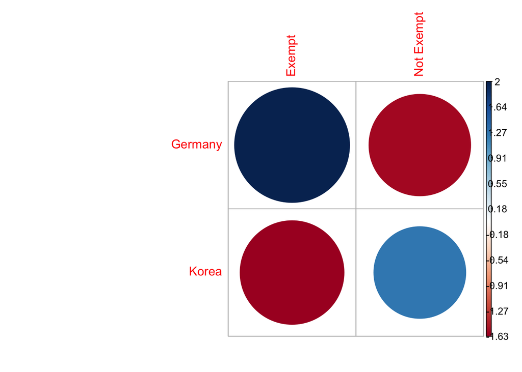

```r
library(corrplot)
corrplot(chisq.test(tbl4)$residuals, is.cor = FALSE)
```

#### Effect Size for Chi-Squared Test

For 2x2 contingency tables, we use phi as our effect size, which is calculated as the square root of the chi-squared value divided by the number of observations. Note that the psych package results in a slightly different number, most due to rounding.

Phi can be interpreted in the same way as Pearson correlations, where .100 to .299 is a small effect, .300 to .599 is a medium effect, and .600 and above is a large effect. As we see below, our effect size is .33, which is a medium effect.

```r
sqrt(9.4245/100) #phi by hand
```

```
## [1] 0.3069935
```

```r
library(psych)
phi(tbl4) #phi using the psych package
```

```
## [1] 0.33
```

Note that for larger contingency tables, Cramer’s V is appropriate. This can be computed in R using the “lsr” package